# DS202 Final Project

Alison Wyatt

2023-05-04

Team members: Alison Wyatt, Kylie Knudten

github link: https://github.com/aawyatt/DS202-Final-Project Our github additionally includes a screenshot of the map plot in the case that it takes too long to load for you.

Data set: We got this dataset from Kaggle.

```r
ufo = read.csv("https://raw.githubusercontent.com/aawyatt/DS202-Final-Project/main/complete.csv")
```

Our question: Is there a region of the US that has the most UFO sightings?

```r
library(dplyr)
library(stringr)
library(lubridate)
```

```r
library(ggplot2)
```

## Step 1: Cleaning

Note: Because of the need for 10 variables, we have included one more variable from what was included in our HW 11 submission (‘datetime’) and joined another data set to get a new variable of state ‘region’.

```r
# Steps for cleaning the dataset:

# 1. Filter out all countries except for country = "us".
ufo1 = ufo %>% filter(ufo$country == "us")

# 2. Capitalize state and city values for cleanliness.
ufo1 = ufo1 %>% mutate(state = toupper(state), city = str_to_title(city))

#3. Extract just the year value from date.posted variable.
ufo1$date.posted = mdy(ufo1$date.posted)
ufo1 = ufo1 %>% mutate(date.posted = year(date.posted))

# 4. Extract just the time value from the datetime variable.
ufo1$datetime = mdy_hm(ufo1$datetime)
ufo1 = ufo1 %>% mutate(datetime = hour(datetime))

library(maps)
# states data
states = map_data("state") %>% mutate(region = str_to_title(region)) %>% rename(State = region)
# table with the states/abbreviations
abbr = read.csv("https://raw.githubusercontent.com/jasonong/List-of-US-States/master/states.csv")
# table with regions
region = read.csv("https://raw.githubusercontent.com/cphalpert/census-regions/master/us%20census%20bureau%20regions%20and%20divisions.csv")


ufo1 = ufo1 %>% rename(Abbreviation = state) %>% filter(Abbreviation != "PR")

ufo1 = right_join(ufo1, abbr, by = "Abbreviation")
# states for which we do not have map data
nomatch1 = ufo1 %>% anti_join(states, by = "State")
#unique(nomatch1$State)
# states for which we do not have ufo data
nomatch2 = states %>% anti_join(ufo1, by = "State")
#unique(nomatch2$State)
# remove data for which we don't have map/ufo data for
ufo1 = ufo1 %>% filter(!(State %in% c("Hawaii", "Alaska", "District of Columbia")))
# add state map information to ufo1
ufo1 = ufo1 %>% left_join(states, by = "State") %>% select(-order, -subregion)
# add region information to ufo1
ufo1 = ufo1 %>% left_join(region, by = "State") %>% select(-State.Code, -Division)

# get rid of unnecessary columns
ufo1 = ufo1 %>% select(-duration..hours.min., -comments)

# rename long/lat variables for clarity
ufo1 = ufo1 %>% rename(long.border = long, lat.border = lat)
```

## Step 2: Visual summary (6 out of 8 candidate plots)

### Bar graph (state breakdown and top 5 cities)

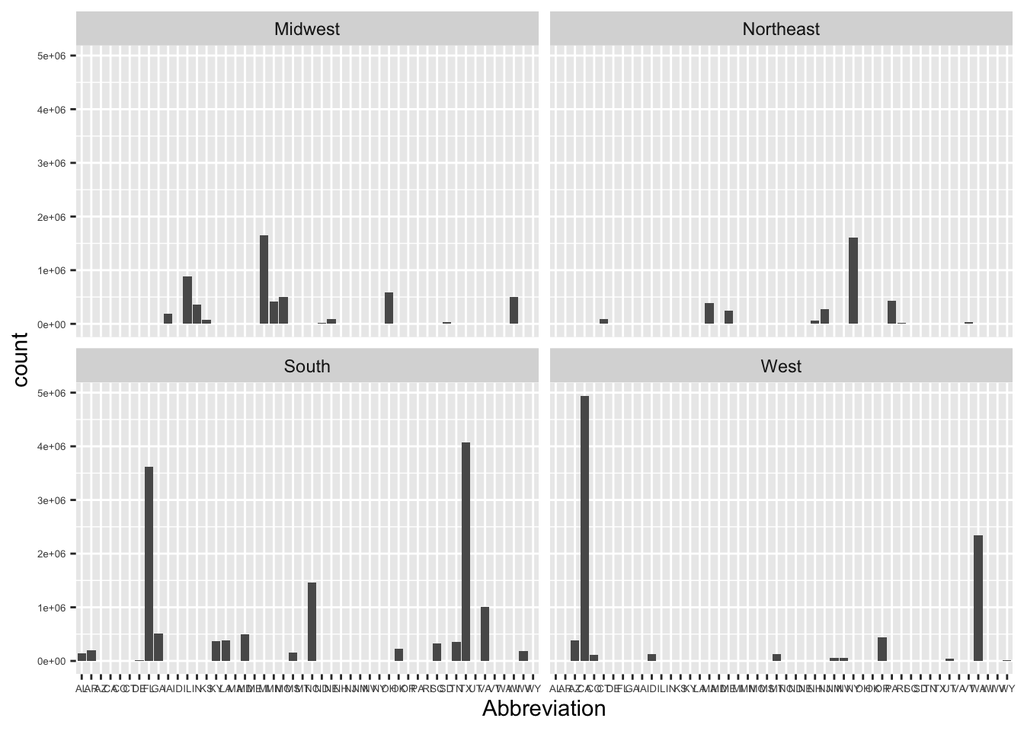

```r
# Overall look at sightings by state
ufo1 %>% group_by(Region, Abbreviation) %>% count() %>% ggplot(aes(x = Abbreviation)) + geom_bar(aes(weight = n)) + theme(axis.text = element_text(size = 5)) + facet_wrap(~Region)
```

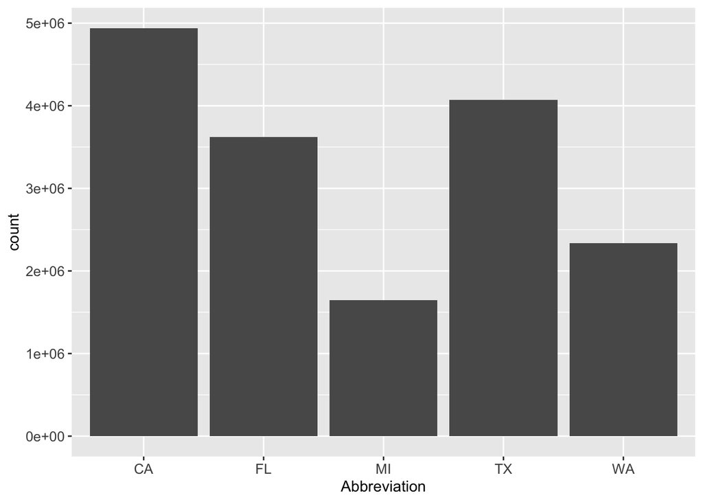

```r
# Top 5 states with most sightings
ufo2 = ufo1 %>% group_by(Abbreviation) %>% summarise(n=n()) %>% arrange(desc(n))
ufo2 = ufo2[1 : 5, ]
ufo2 %>% ggplot(aes(x = Abbreviation)) + geom_bar(aes(weight = n)) + theme(axis.text = element_text(size = 5), axis.text.x=element_text(size=10),axis.text.y=element_text(size=10))
```

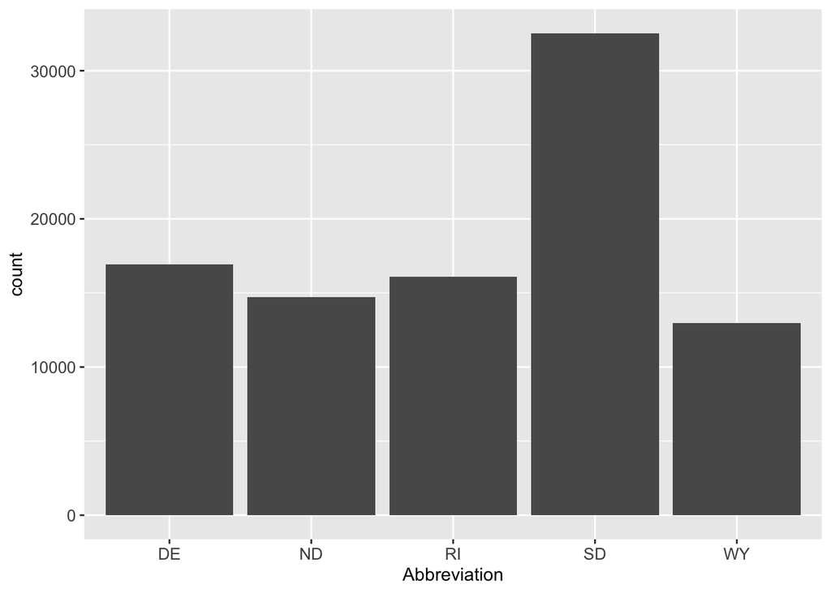

```r
# Bottom 5 states with least sightings
ufo3 = ufo1 %>% group_by(Abbreviation) %>% summarise(n=n()) %>% arrange(n)
ufo3 = ufo3[1 : 5, ]
ufo3 %>% ggplot(aes(x = Abbreviation)) + geom_bar(aes(weight = n)) + theme(axis.text = element_text(size = 5), axis.text.x=element_text(size=10),axis.text.y=element_text(size=10))
```

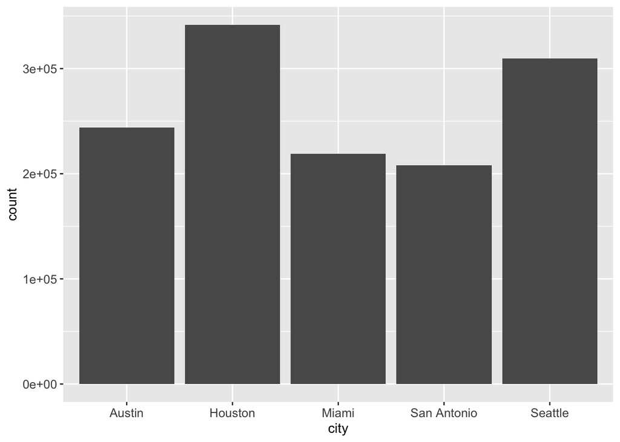

```r
# Top 5 cities with most sightings
ufo4 = ufo1 %>% group_by(city) %>% summarise(n=n()) %>% arrange(desc(n))
ufo4 = ufo4[1 : 5, ]
ufo4 %>% ggplot(aes(x = city)) + geom_bar(aes(weight = n)) + theme(axis.text = element_text(size = 5), axis.text.x=element_text(size=10),axis.text.y=element_text(size=10))
```